# Vegetables Prices Analysis in Kathmandu Valley: Onion

```r
Onion_constant_prices <- Onion |>
  inner_join(cpi, by = join_by(Date)) |>
  mutate(Average_constant_prices = Average / CPI) |>
  select(Date, Commodity, Average_constant_prices)
head(Onion_constant_prices, 5)
```

```
## # A tsibble: 5 x 3 [1M]
## # Key:       Commodity [1]
##       Date Commodity          Average_constant_prices
##      <mth> <chr>                                <dbl>
## 1 2013 Aug Onion Dry (Indian)                    74
## 2 2013 Sep Onion Dry (Indian)                    90.0
## 3 2013 Oct Onion Dry (Indian)                    98.6
## 4 2013 Nov Onion Dry (Indian)                    88.7
## 5 2013 Dec Onion Dry (Indian)                    42.5
```

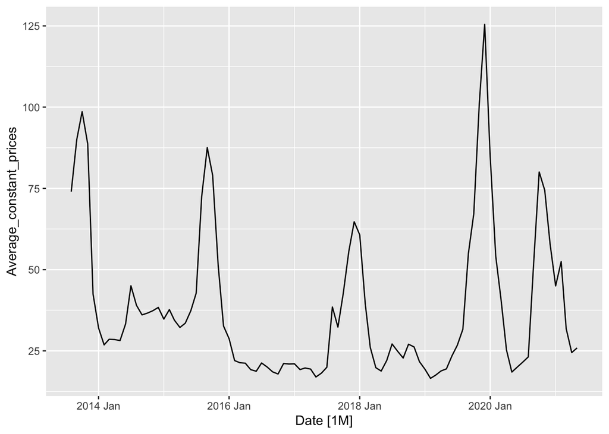

```r
Onion_constant_prices %>%
  features(Average_constant_prices, features = guerrero) %>%
  pull(lambda_guerrero)-> lambda

Onion_constant_prices %>% autoplot(Average_constant_prices)
```

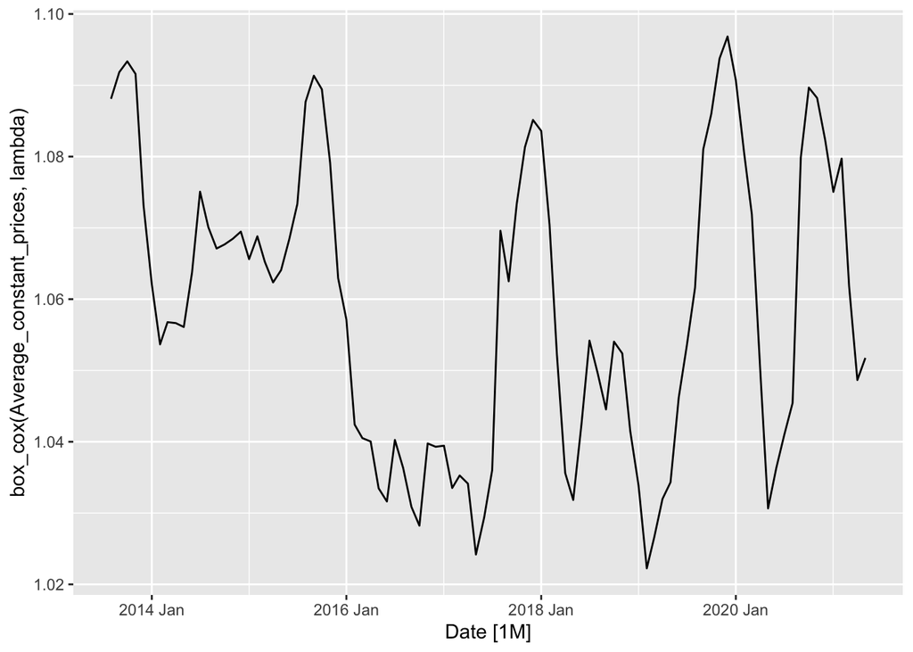

```r
Onion_constant_prices %>%
  autoplot(box_cox(Average_constant_prices, lambda))
```

# Decomposition models We choose various decomposition models for the Onion to evaluate which one is the best. When it comes to the STL2 model we set window 72 in the trend to catch any trend in the span of our data, and season window to 24 to match our seasonal lag at 24 (cyclic behavior). In the plot below we can see that the best suited decomposition model is the X13 (Arima Seats) because it captures the trend and the seasonality/cyclic pattern the best out of all models.

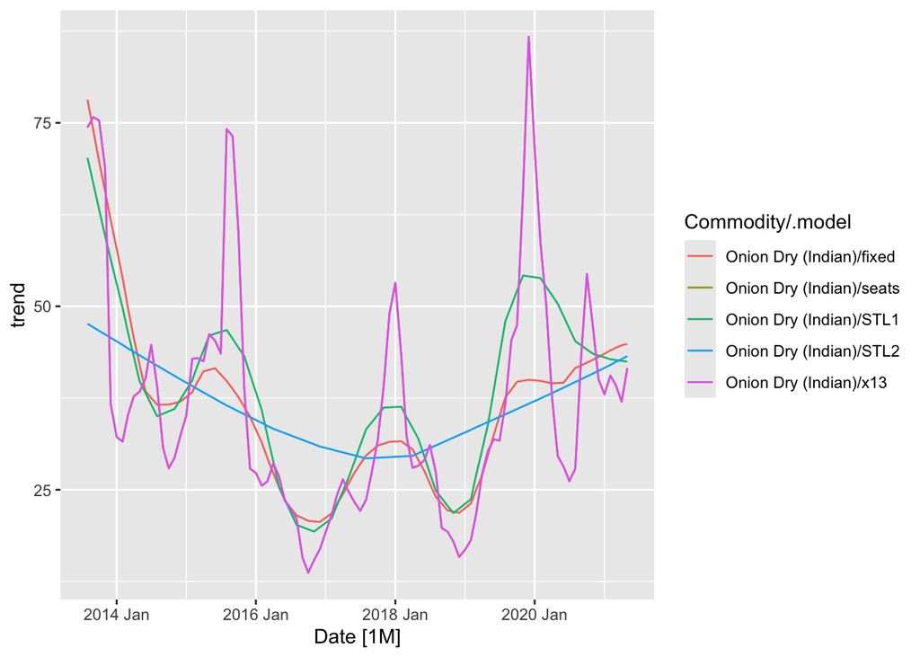

```r
Onion_constant_prices %>%
  model(STL1 = STL(Average_constant_prices),
        STL2 = STL(Average_constant_prices ~ trend(window = 72 ) + season(window = 24), robust = TRUE),
        fixed = STL(Average_constant_prices ~ season(window = "periodic"), robust = TRUE),
        x13 = X_13ARIMA_SEATS(Average_constant_prices),
        seats = X_13ARIMA_SEATS(Average_constant_prices ~ seats()))%>%
  components() -> dcmpOnion

dcmpOnion %>% as_tsibble() %>% autoplot(trend)
```

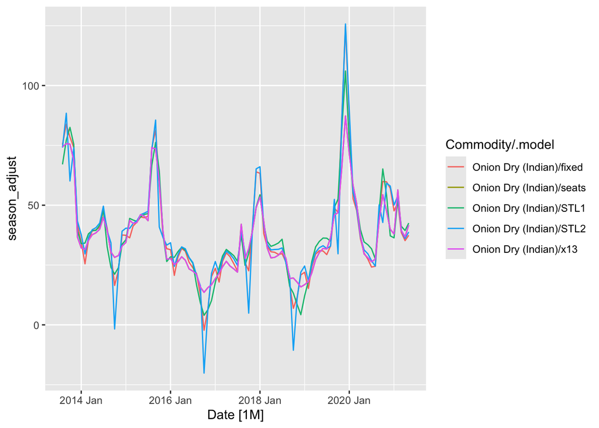

```r
dcmpOnion %>% as_tsibble() %>% autoplot(season_adjust)
```

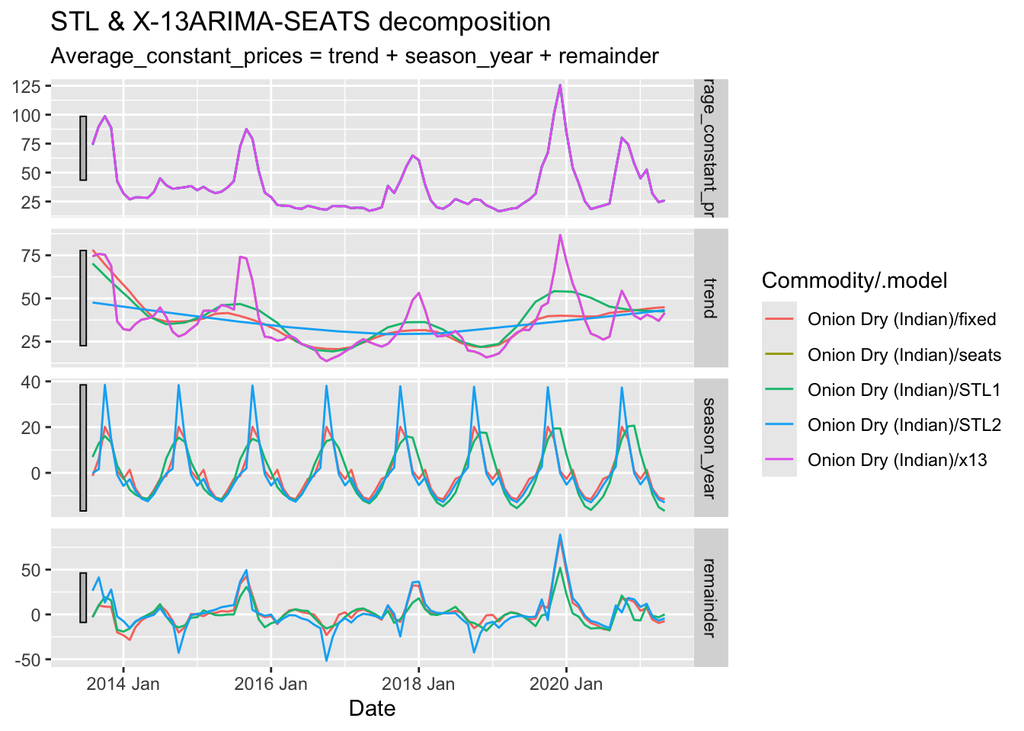

```r
autoplot(dcmpOnion)
```

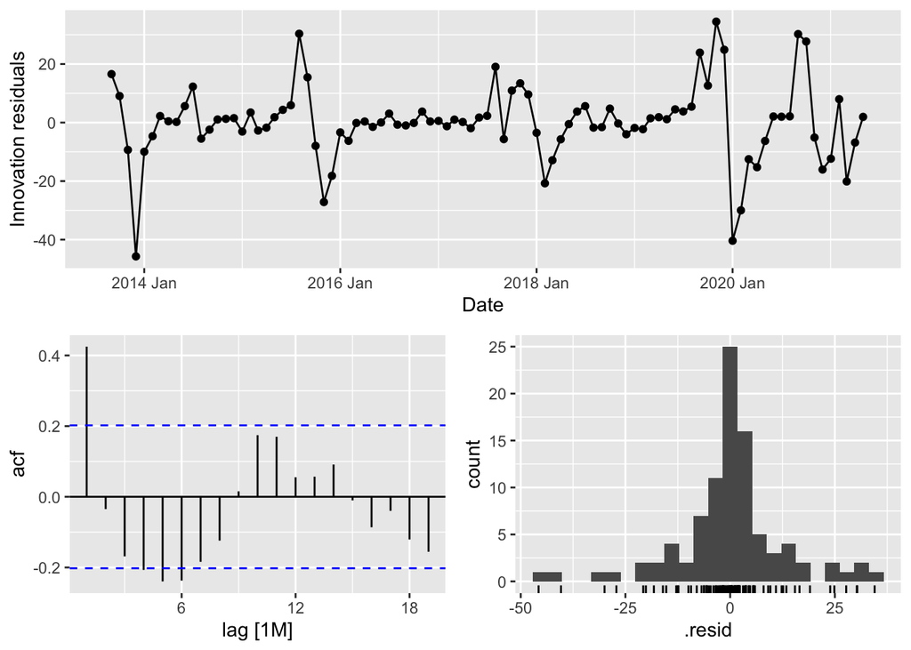

```r
Onion_X13 <- Onion_constant_prices %>%
  model(RW(Average_constant_prices ~ drift()))

Onion_X13 %>% gg_tsresiduals()
```

```r
num_rows <- nrow(Onion_constant_prices)
print(num_rows)
```

```
## [1] 94
```

```r
train_onion <- Onion_constant_prices %>% slice(1:(n() - 60))

fit_onion <- train_onion %>%
  model(
    Naive = NAIVE(Average_constant_prices),
    Seasonal_Naive = SNAIVE(Average_constant_prices),
    Drift = RW(Average_constant_prices ~ drift()),
    Mean = MEAN(Average_constant_prices)
  )

fit_onion %>% accuracy() %>% arrange(RMSE)
```

```
## # A tibble: 4 × 11
##   Commodity    .model .type        ME  RMSE   MAE    MPE  MAPE  MASE RMSSE  ACF1
##   <chr>        <chr>  <chr>     <dbl> <dbl> <dbl>  <dbl> <dbl> <dbl> <dbl> <dbl>
## 1 Onion Dry (… Drift  Trai…  2.20e-15  12.6  8.03  -2.35  17.4 0.394 0.449 0.430
## 2 Onion Dry (… Naive  Trai… -1.66e+ 0  12.8  7.95  -7.00  17.5 0.390 0.453 0.430
## 3 Onion Dry (… Mean   Trai…  8.36e-16  22.0 17.2  -21.2   41.7 0.842 0.782 0.791
## 4 Onion Dry (… Seaso… Trai… -4.56e+ 0  28.2 20.4  -26.4   51.7 1     1     0.795
```

When specifically looking at best model for forecasting (for a 24 month period due to our cyclic behavior) to see how the different models compare, it is clear here that no model is too good and that even the best model is bad, as evidenced by its poor residual that does not resemble white noise.

```r
fit_onion %>% forecast(h = 24) %>% accuracy(Onion_constant_prices)%>% arrange(RMSE)
```

```
## # A tibble: 4 × 11
##   .model        Commodity .type     ME  RMSE   MAE   MPE  MAPE  MASE RMSSE  ACF1
##   <chr>         <chr>     <chr>  <dbl> <dbl> <dbl> <dbl> <dbl> <dbl> <dbl> <dbl>
## 1 Naive         Onion Dr… Test    8.77  16.7  9.29  18.4  21.4 0.456 0.593 0.832
## 2 Mean          Onion Dr… Test  -15.9   21.3 20.0  -86.4  93.1 0.982 0.757 0.832
## 3 Seasonal_Nai… Onion Dr… Test  -15.0   30.3 22.5  -77.5  91.9 1.11  1.08  0.791
## 4 Drift         Onion Dr… Test   29.5   37.0 29.5   98.0  98.0 1.45  1.32  0.899
```

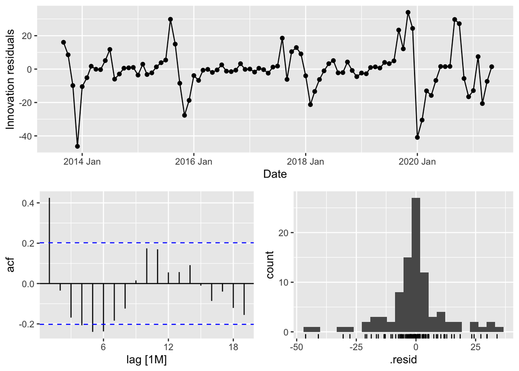

```r
onion_drift <- Onion_constant_prices %>% model(NAIVE(Average_constant_prices))
onion_drift %>% gg_tsresiduals()
```

## 5. Exponential smoothing

Looking at the Onion ACF we can see that it is stationary. Since we already have evaluated the data and we know that we have both seasonality and cyclic behavior we would suggest that we have a multiplicative error and seasonality, to capture all of these different changes in the onion price over time, also because the onion increase and decrease a lot over time and showcase variation. Since the trend is not very apparent we can use a N on the trend. the model would hence me a MNM-model.The best model for the onion out of the models below is the MNM-model, that is also the model that was chosen when performing ETS. So far this is the best model we have seen so far, even if we still have significant lags in the residuals (ACF).

```r
Onion_ExponentialSmoothing <- Onion_constant_prices %>%
  model(MNM = ETS(Average_constant_prices ~ error("M") + trend("N") + season("M")),
        holt = ETS(Average_constant_prices ~ error("A") + trend("A") + season("N")),
        ses = ETS(Average_constant_prices ~ error("A") + trend("N") + season("N")),
        ETS = ETS(Average_constant_prices))

report(Onion_ExponentialSmoothing)
```

```
## # A tibble: 4 × 10
##   Commodity          .model   sigma2 log_lik   AIC  AICc   BIC   MSE  AMSE   MAE
##   <chr>              <chr>     <dbl>   <dbl> <dbl> <dbl> <dbl> <dbl> <dbl> <dbl>
## 1 Onion Dry (Indian) MNM      0.0607   -403.  836.  843.  875.  125.  293. 0.180
## 2 Onion Dry (Indian) holt   175.       -454.  919.  919.  931.  168.  460. 8.40
## 3 Onion Dry (Indian) ses    166.       -453.  912.  912.  919.  163.  467. 8.22
## 4 Onion Dry (Indian) ETS      0.0607   -403.  836.  843.  875.  125.  293. 0.180
```

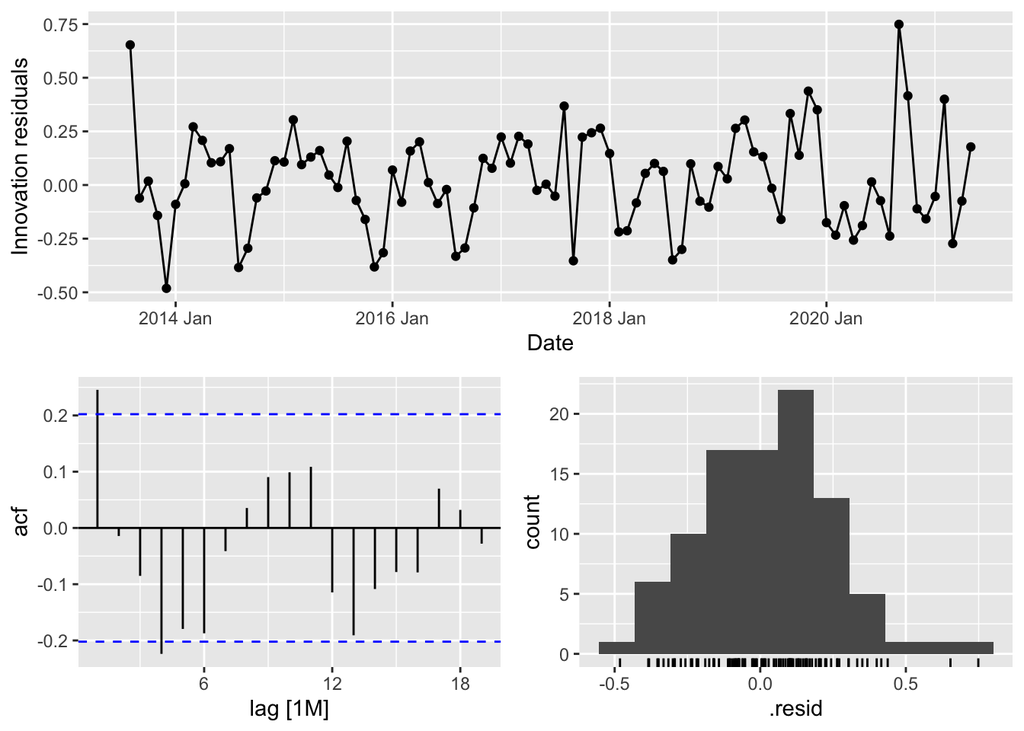

```r
OnionMNM <- Onion_constant_prices %>% model(ses = ETS(Average_constant_prices ~ error("M") + trend("N") + season("M")))

OnionMNM %>% gg_tsresiduals()
```

```r
OnionMNM %>%
  tidy()
```

```
## # A tibble: 15 × 4
##    Commodity          .model term    estimate
##    <chr>              <chr>  <chr>      <dbl>
##  1 Onion Dry (Indian) ses    alpha   0.989
##  2 Onion Dry (Indian) ses    gamma   0.000125
##  3 Onion Dry (Indian) ses    l[0]   44.2
##  4 Onion Dry (Indian) ses    s[0]    0.718
##  5 Onion Dry (Indian) ses    s[-1]   0.619
##  6 Onion Dry (Indian) ses    s[-2]   0.581
##  7 Onion Dry (Indian) ses    s[-3]   0.647
##  8 Onion Dry (Indian) ses    s[-4]   0.782
##  9 Onion Dry (Indian) ses    s[-5]   0.934
## 10 Onion Dry (Indian) ses    s[-6]   1.12
## 11 Onion Dry (Indian) ses    s[-7]   1.37
## 12 Onion Dry (Indian) ses    s[-8]   1.48
## 13 Onion Dry (Indian) ses    s[-9]   1.42
## 14 Onion Dry (Indian) ses    s[-10]  1.32
## 15 Onion Dry (Indian) ses    s[-11]  1.01
```

```r
Onion_ExponentialSmoothing %>% glance()
```

```
## # A tibble: 4 × 10
##   Commodity          .model   sigma2 log_lik   AIC  AICc   BIC   MSE  AMSE   MAE
##   <chr>              <chr>     <dbl>   <dbl> <dbl> <dbl> <dbl> <dbl> <dbl> <dbl>
## 1 Onion Dry (Indian) MNM      0.0607   -403.  836.  843.  875.  125.  293. 0.180
## 2 Onion Dry (Indian) holt   175.       -454.  919.  919.  931.  168.  460. 8.40
## 3 Onion Dry (Indian) ses    166.       -453.  912.  912.  919.  163.  467. 8.22
## 4 Onion Dry (Indian) ETS      0.0607   -403.  836.  843.  875.  125.  293. 0.180
```

# Arima

Our data is already stationary so we do not need to do any difference! Looking at our the ACF and PACF we see that we have two significant lags in the PACF (lag 1 and 2) indicating that an AR model of order 2 could be suitable. In the ACF we have also the first two lags as significant, but we also have two more ‘’barely’’ significant lags, hence we choose to try the AR2 model which in this context makes the most sense, because of it’s simplicity.

Both of these models have residuals that resemble white noise and hence, we have finally found a good forecasting model for the onion!

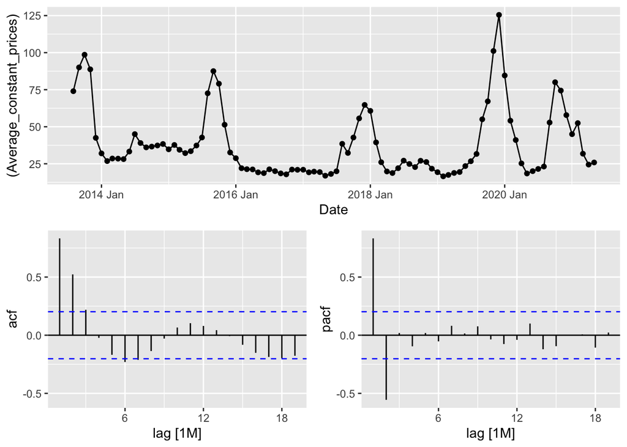

```r
Onion_constant_prices %>% gg_tsdisplay((Average_constant_prices), plot_type = "partial")
```

```r
Onion_fit <- Onion_constant_prices %>%
  model(Arima2 = ARIMA(Average_constant_prices ~ pdq(2,0,0)),
    auto = ARIMA(Average_constant_prices, stepwise = FALSE, approx = FALSE))

glance(Onion_fit) %>%
         arrange(AICc) %>%
         select(.model:BIC)
```

```
## # A tibble: 2 × 6
##   .model sigma2 log_lik   AIC  AICc   BIC
##   <chr>   <dbl>   <dbl> <dbl> <dbl> <dbl>
## 1 auto     98.7   -350.  711.  712.  726.
## 2 Arima2  106.    -352.  712.  713.  722.
```

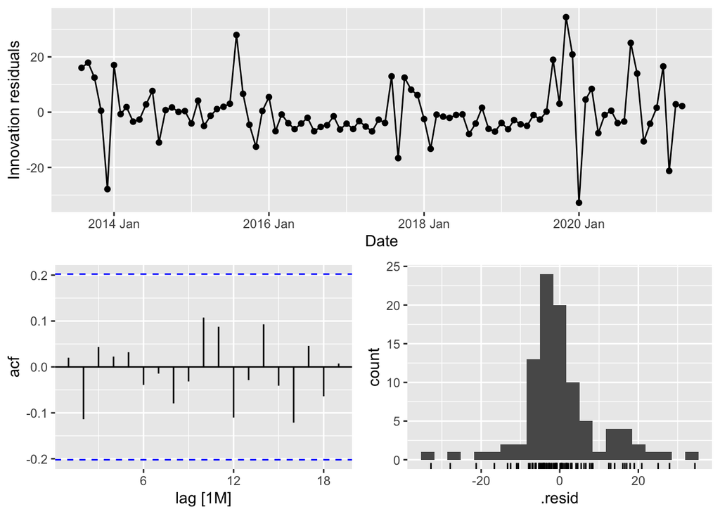

```r
Onion_fit %>%
  select(Arima2) %>%
  gg_tsresiduals()
```

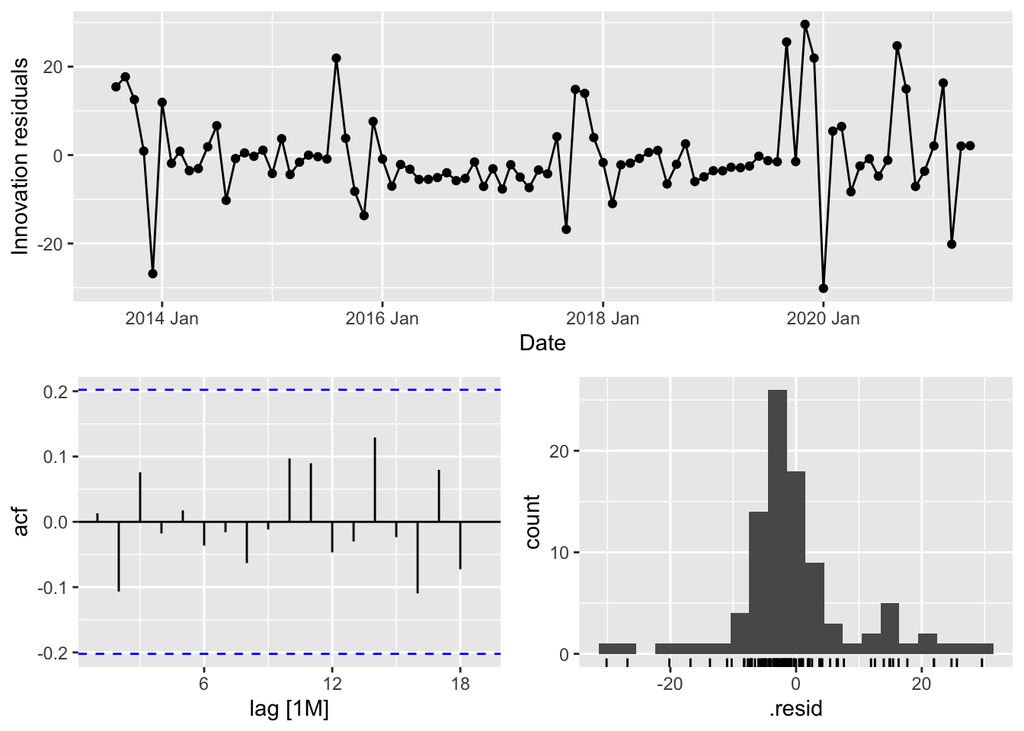

```r
Onion_fit %>%
  select(auto) %>%
  gg_tsresiduals()
```